## Chargement des packages et des données

```r
library(tidyverse)
```

```r
plastic_waste <- read_csv("data/plastic-waste.csv")
```

Commençons par filtrer les données pour retirer le point représenté par Trinité et Tobago (TTO) qui est un outlier.

```r
plastic_waste <- plastic_waste %>%
  filter(plastic_waste_per_cap < 3.5)
```

## Exercices

### Exercise 1

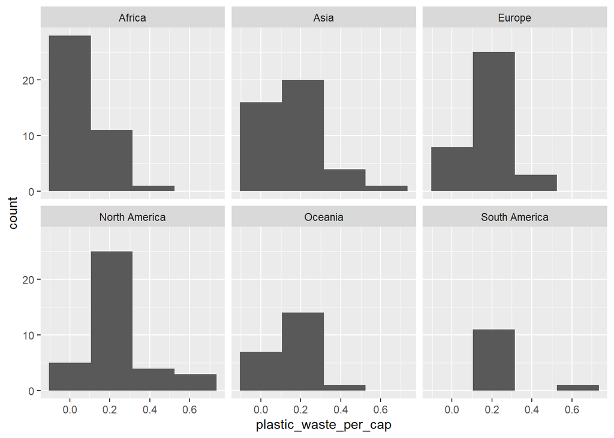

```r
plastic_waste <- plastic_waste %>%
  filter(plastic_waste_per_cap <3.5)
ggplot(plastic_waste,aes(x=plastic_waste_per_cap))+
  geom_histogram(binwidth=0.21)+
  facet_wrap(~continent,ncol=3)
```

Il est possible d’observer que pour tous les continents excepté l’Afrique ont plus de pays ayant environ 0.2 de gaspillage plastique par habitant que de pays qui en ont presque 0. Cela signifie en bref qu’il y a beaucoup moins de gaspillage par personne en Afrique que dans tous les autres continents.

### Exercise 2

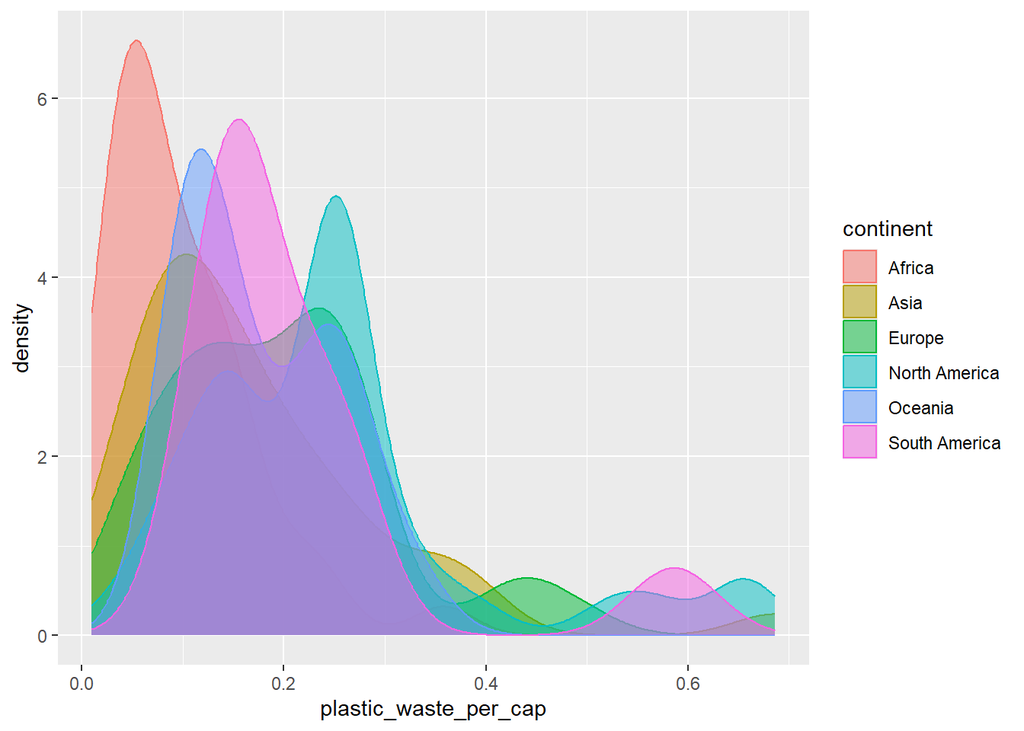

```r
plastic_waste <- plastic_waste %>%
  filter(plastic_waste_per_cap<3.5)
ggplot(plastic_waste,aes(x=plastic_waste_per_cap,fill=continent,color=continent))+
  geom_density(alpha=0.5)
```

Le réglage de la couleur (color et fill) se trouve dans la parenthèse du aes (aesthetics) puisque ces paramètres sont associés avec des variables du jeu de données. En effet, chaque couleur est associée avec un continent et si on en retire un, les couleurs vont changer. Au contraire, le réglage de la transparence (alpha) ne se situe par dans l’aesthetics puisque la transparence ne change pas avec une variable. Si on retire un continent de la liste, il n’y a aucun effet sur la transparence.

### Exercise 3

Boxplot:

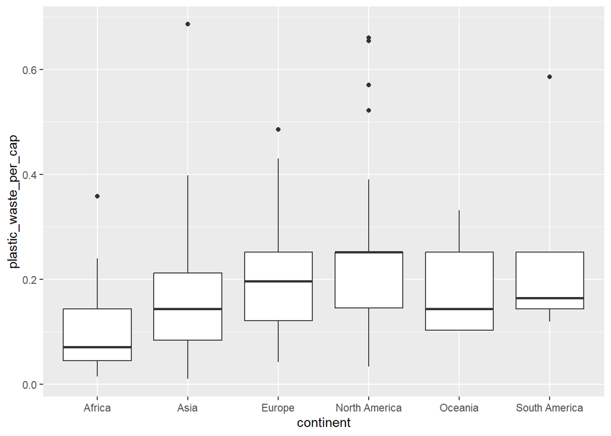

```r
plastic_waste <- plastic_waste %>%
  filter(plastic_waste_per_cap<3.5)
ggplot(plastic_waste,aes(x=continent, y=plastic_waste_per_cap))+
  geom_boxplot()
```

Violin plot:

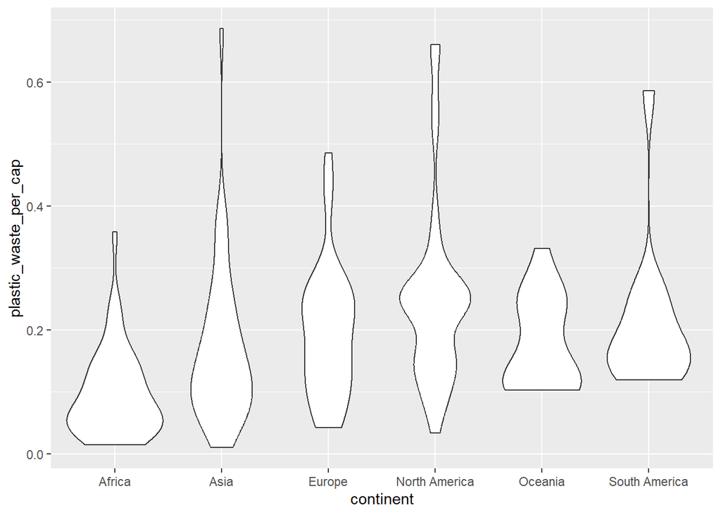

```r
plastic_waste <- plastic_waste %>%
  filter(plastic_waste_per_cap<3.5)
ggplot(plastic_waste,aes(x=continent, y=plastic_waste_per_cap))+
  geom_violin()
```

Les violons, au contraire des boites, permettent de voir la distribution à l’intérieur du 50% des données qui se situent dans la section blanche.

### Exercise 4

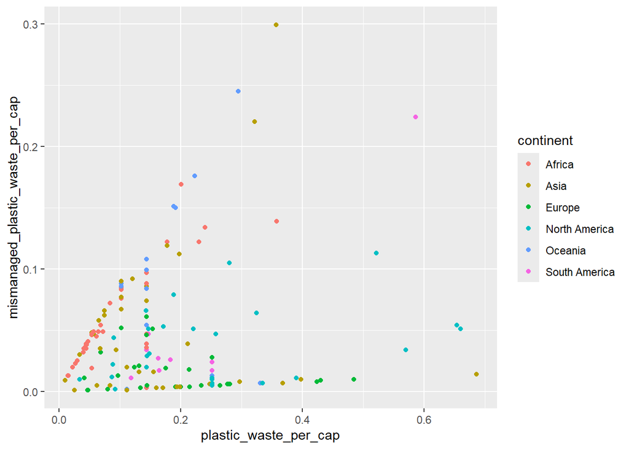

```r
plastic_waste <- plastic_waste %>%
  filter(plastic_waste_per_cap<3.5)
ggplot(plastic_waste,aes(x=plastic_waste_per_cap, y=mismanaged_plastic_waste_per_cap, color=continent))+
  geom_point()
```

Si on considère tous les continents, on peut voir qu’il n’y a aucun pays qui se débarasse de tous les déchets qu’il crée. En observant chaques continents spécifiques, il est possible de voir que les continents comme l’Afrique et l’Océanie se débarassent plus des déchets qu’ils créent que d’autres continent comme l’Europe et l’Amérique du Nord. L’Asie est un continent est un peu spécial puisque la distribution des pays est très vairée. Il y a autant de pays avec peu de déchets ou qui se débarassent de la plupart de ce qu’ils créent que de pays qui ont une grande production de déchets et se débarassent de presque aucun déchets.